# Mini project 2: primary productivity in coastal waters

In this project you're again given a dataset and some questions. The data for this project come from the [EPA's National Aquatic Resource Surveys](https://www.epa.gov/national-aquatic-resource-surveys/data-national-aquatic-resource-surveys), and in particular the National Coastal Condition Assessment (NCCA); broadly, you'll do an exploratory analysis of primary productivity in coastal waters.

By way of background, chlorophyll A is often used as a proxy for [primary productivity in marine ecosystems](https://en.wikipedia.org/wiki/Marine_primary_production); primary producers are important because they are at the base of the food web. Nitrogen and phosphorus are key nutrients that stimulate primary production.

In the data folder you'll find water chemistry data, site information, and metadata files. It might be helpful to keep the metadata files open when tidying up the data for analysis. It might also be helpful to keep in mind that these datasets contain a considerable amount of information, not all of which is relevant to answering the questions of interest. Notice that the questions pertain somewhat narrowly to just a few variables. It's recommended that you determine which variables might be useful and drop the rest.

As in the first mini project, there are accurate answers to each question that are mutually consistent with the data, but there aren't uniquely correct answers. You will likely notice that you have even more latitude in this project than in the first, as the questions are slightly broader. Since we've been emphasizing visual and exploratory techniques in class, you are encouraged (but not required) to support your answers with graphics.

The broader goal of these mini projects is to cultivate your problem-solving ability in an unstructured setting. Your work will be evaluated based on the following:

- choice of method(s) used to answer questions;
- clarity of presentation;
- code style and documentation.

Please write up your results separately from your codes; codes should be included at the end of the notebook.

```python
Author: Neala Rashidfarrukhi
Collaborator: Eve McCreary
```

## Part 1: dataset

Merge the site information with the chemistry data and tidy it up. Determine which columns to keep based on what you use in answering the questions in part 2; then, print the first few rows here (but *do not include your codes used in tidying the data*) and write a brief description (1-2 paragraphs) of the dataset conveying what you take to be the key attributes. Direct your description to a reader unfamiliar with the data; ensure that in your data preview the columns are named intelligibly.

*Suggestion*: export your cleaned data as a separate `.csv` file and read that directly in below, as in: `pd.read_csv('YOUR DATA FILE').head()`.

```python
Final_Data.head(10)
```

|  | Chlorophyll A | Total Nitrogen | Total Phosphorus | STATE | WTBDY_NM | WGT_NCCA10 | ALAT_DD | ALON_DD | NCCR_REG | DATE_COL | STATION_DEPTH | NCA_REGION | Seasons |
| --- | --- | --- | --- | --- | --- | --- | --- | --- | --- | --- | --- | --- | --- |
| 0 | 3.34 | 0.407500 | 0.061254 | CA | Mission Bay | 2.503632 | 32.77361 | -117.21471 | West | 1-Jul-10 | 2.5 | West Coast | Jul |
| 1 | 2.45 | 0.230000 | 0.037379 | CA | San Diego Bay | 5.255002 | 32.71424 | -117.23527 | West | 1-Jul-10 | 3.5 | West Coast | Jul |
| 2 | 3.82 | 0.336250 | 0.048100 | CA | Mission Bay | 2.503632 | 32.78372 | -117.22132 | West | 1-Jul-10 | 2.2 | West Coast | Jul |
| 3 | 6.13 | 0.238750 | 0.044251 | CA | San Diego Bay | 5.255002 | 32.72245 | -117.20443 | West | 1-Jul-10 | 9.5 | West Coast | Jul |
| 4 | 9.79 | 0.632500 | 0.090636 | NC | White Oak River | 75.994127 | 34.75098 | -77.12117 | Southeast | 9-Jun-10 | 1.0 | East Coast | Jun |
| 5 | 3.04 | 0.164375 | 0.015377 | NC | Back Sound | 152.163444 | 34.69108 | -76.58123 | Southeast | 22-Jun-10 | 2.2 | East Coast | Jun |
| 6 | 7.51 | 0.443000 | 0.036338 | NC | Pamlico Sound | 811.558535 | 35.16013 | -76.23504 | Southeast | 16-Jun-10 | 6.0 | East Coast | Jun |
| 7 | 10.96 | 0.535625 | 0.078323 | NC | Bogue Sound | 245.435557 | 34.72364 | -76.89447 | Southeast | 22-Jun-10 | 0.7 | East Coast | Jun |
| 8 | 13.63 | 0.608750 | 0.058334 | NC | Upper Broad Creek | 117.333012 | 35.10536 | -76.93667 | Southeast | 2-Jun-10 | 1.3 | East Coast | Jun |
| 9 | 6.42 | 0.712500 | 0.047309 | NC | Lockwood Follys River | 79.134439 | 33.94715 | -78.22403 | Southeast | 7-Jun-10 | 2.5 | East Coast | Jun |

## Part 2: exploratory analysis

Answer each question below and provide a visualization supporting your answer. A description and interpretation of the visualization should be offered.

*Comment:* you can either designate your plots in the codes section with clear names and reference them in your answers; or you can export your plots as image files and display them in markdown cells.

### What is the apparent relationship between nutrient availability and productivity?

*Comment*: it's fine to examine each nutrient -- nitrogen and phosphorus -- separately, but do consider whether they might be related to each other.

*We examined Total Phosphorus and Total Nitrogen against Chlorophyll A. From these two graphs we can see that as nutrients increases, ptoductivity increases with it. Both graphs have a positive correlation with very few outliars. In many coastal regions in the given data, Total Phosphorus and Total Nitrogen are nurtients found in the same body of water. From this we can conclude that the presence of both nitrogen and phosphorus increases the presence of Chlorophyll A.

The reasons for this is because with the increase of Nitrogen and Phosphorus it causes certain components in the water like algae to bloom, thus producing more Chlorophyll A.*

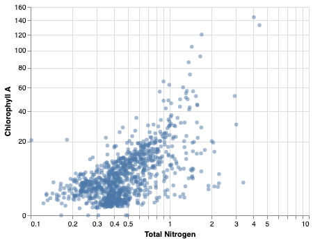

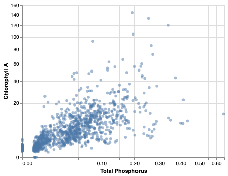

### Are there any notable differences in available nutrients among U.S. coastal regions?

In the second graph we can clearly see that there is far less amounts of Total Phosphorus compared to Total Nitrogen. For Total Phosphorus and Chlorophyll A we can see that Phosphorus and Chlorophyll A is more apparent in the East Coast and the Great Lakes compared to the Gulf Coast and West Cost. There are not as many apparent outliers within this data in constrast to the Total Nitrogen vs. Chlorophyll A data. Also, we can see that when Phosphorus is at about .18 phosphorus will drop thus, Chlorophyll A drops but then Phosphorus increases again at .23 and so does Chlorophyll A Productivity.

From this data we can conclude that there is a direct relationship between Productivity and Nutrients and when either Total Nitrogen or Total Phosphorus increase or decrease, Chlorophyll A will increase or decrease with them.*

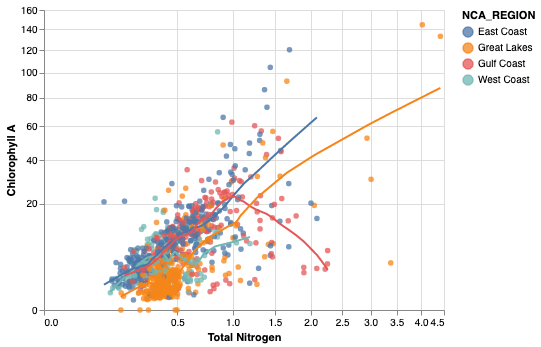

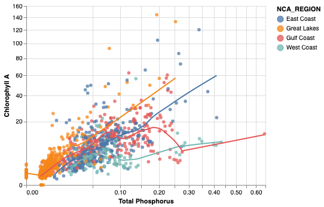

### Based on the 2010 data, does productivity seem to vary geographically in some way?

If so, explain how; If not, explain what options you considered and ruled out.

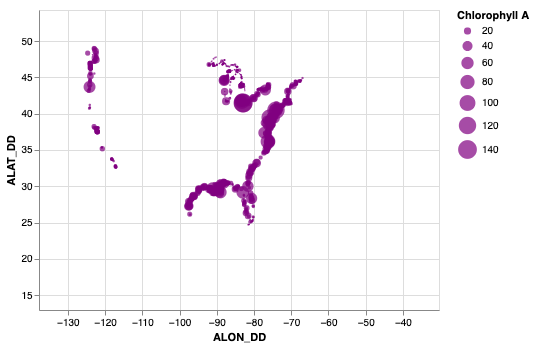

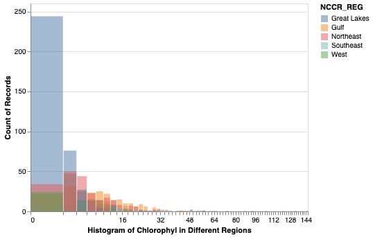

### How does primary productivity in California coastal waters change seasonally in 2010, if at all?

Does your result make intuitive sense?

*From the graphs we can that productivity is very high within the summer months. For Nitrogen, the months June and July have the highest amounts of productivty. This is due to the increase in Nitrogen and Phosphorus within the water during the hotter months since materials in the atmosphere like Nitrogen and Phosphorus sink lower during the warmer months, thus causing Chlorophyll A to increase. Additionally we can see that phosphorus is strictly increasing within July but is fluctuating within the other summer months with respect to Chlorophyll A. Since there are less data points for phosphorus it is more clear to see the data changing over the course of the months.

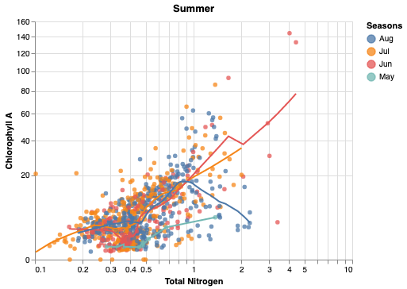

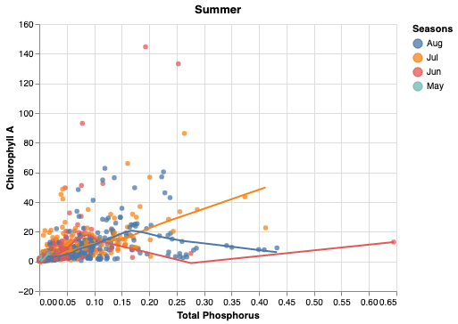

In Autumn we can see that productivity increases drastically since Nitrogen increases drastically within the Autumn seasons. There is much more Nitrogen present in comparison to Phosphorus. There is still an increase within the Autumn seasons with Phosphorus as well but there is not much of a drastic increase. There is much more nitrogen and Phosphorus present within September compared to October, thus we can conclude as the weather gets colder there is less nutrtients present in the water.

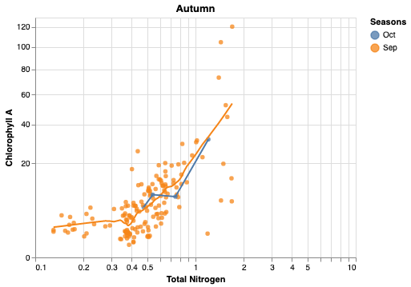

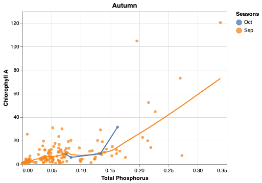

Overall, from our data we can conclude that as the weather gets colder there is less nutrients within the water so productivity decreases within the colder months.*

### Does the depth of the water in coastal waters change productivity monthly in 2010?

*As we can see from the data, each months follows a very similar distirbution. When the depth of the water is anywhere from 0-40, the productivity of Chlorophyll A is anywhere from 0-40. We can see that productvity is most consisntent within August and July and that there is a steady, slow productivity increase. In every month productivity seems to spike when the water depth is around 10. We can also see that over productivty is the lowest for the months May and June even where the water depth is around 10.

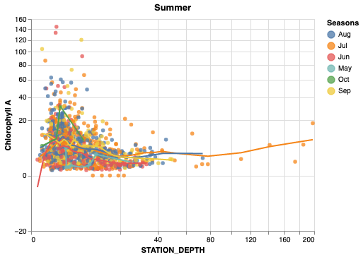

# Codes

```python
import pandas as pd
import numpy as np
import altair as alt

ncca_raw = pd.read_csv('/home/jovyan/pstat100-content/project/mp2/assessed_ncca2010_waterchem.csv')
ncca_sites = pd.read_csv('/home/jovyan/pstat100-content/project/mp2/assessed_ncca2010_siteinfo.csv')
```

```python
# First I am going to create seperate columns for Chlorophyll A, Total Nitrogen and Total Phosphorus
# Select columns and rows we want in new data frame
ncca_loc = ncca_raw.loc[(ncca_raw['PARAMETER_NAME']=='Total Nitrogen') | (ncca_raw['PARAMETER_NAME']=='Total Phosphorus') |
                        (ncca_raw['PARAMETER_NAME']=='Chlorophyll A')].drop(
    columns=['METHOD', 'QACODE','PQL'])
ncca_loc
# pivot to make rows into columns with results as the value
ncca_new_raw = ncca_loc.pivot(index='UID', columns='PARAMETER_NAME', values='RESULT')
# print head
ncca_new_raw.head(20)
```

| PARAMETER_NAME UID | Chlorophyll A | Total Nitrogen | Total Phosphorus |
| --- | --- | --- | --- |
| 59 | 3.34 | 0.407500 | 0.061254 |
| 60 | 2.45 | 0.230000 | 0.037379 |
| 61 | 3.82 | 0.336250 | 0.048100 |
| 62 | 6.13 | 0.238750 | 0.044251 |
| 63 | 9.79 | 0.632500 | 0.090636 |
| 64 | 3.04 | 0.164375 | 0.015377 |
| 65 | 7.51 | 0.443000 | 0.036338 |
| 66 | 10.96 | 0.535625 | 0.078323 |
| 67 | 13.63 | 0.608750 | 0.058334 |
| 68 | 6.42 | 0.712500 | 0.047309 |
| 69 | 6.38 | 0.228750 | 0.029337 |
| 70 | 6.75 | 0.646250 | 0.062141 |
| 71 | 6.24 | 0.811250 | 0.096895 |
| 72 | 51.14 | 1.308000 | 0.076720 |
| 73 | 6.80 | 0.273750 | 0.044896 |
| 74 | 4.35 | 0.283750 | 0.039639 |
| 109 | 6.87 | 0.903750 | 0.069065 |
| 110 | 7.77 | 0.655000 | 0.104701 |
| 111 | 10.92 | 0.746250 | 0.155904 |
| 177 | 0.76 | 0.262500 | 0.002299 |

```python
# I am selecting all the columns I want in my data
all_data = ncca_new_raw.merge(ncca_sites, on='UID', how='right')
data_clean = all_data[['Chlorophyll A', 'Total Nitrogen', 'Total Phosphorus', 'STATE','WTBDY_NM','WGT_NCCA10','ALAT_DD','ALON_DD','NCCR_REG','DATE_COL','STATION_DEPTH',
                      'NCA_REGION']]
data_clean
```

|  | Chlorophyll A | Total Nitrogen | Total Phosphorus | STATE | WTBDY_NM | WGT_NCCA10 | ALAT_DD | ALON_DD | NCCR_REG | DATE_COL | STATION_DEPTH | NCA_REGION |
| --- | --- | --- | --- | --- | --- | --- | --- | --- | --- | --- | --- | --- |
| 0 | 3.34 | 0.40750 | 0.061254 | CA | Mission Bay | 2.503632 | 32.773610 | -117.214710 | West | 1-Jul-10 | 2.5 | West Coast |
| 1 | 2.45 | 0.23000 | 0.037379 | CA | San Diego Bay | 5.255002 | 32.714240 | -117.235270 | West | 1-Jul-10 | 3.5 | West Coast |
| 2 | 3.82 | 0.33625 | 0.048100 | CA | Mission Bay | 2.503632 | 32.783720 | -117.221320 | West | 1-Jul-10 | 2.2 | West Coast |
| 3 | 6.13 | 0.23875 | 0.044251 | CA | San Diego Bay | 5.255002 | 32.722450 | -117.204430 | West | 1-Jul-10 | 9.5 | West Coast |
| 4 | 9.79 | 0.63250 | 0.090636 | NC | White Oak River | 75.994127 | 34.750980 | -77.121170 | Southeast | 9-Jun-10 | 1.0 | East Coast |
| ... | ... | ... | ... | ... | ... | ... | ... | ... | ... | ... | ... | ... |
| 1099 | NaN | NaN | NaN | MI | Lake Michigan | 3.424502 | 45.845952 | -86.751205 | Great Lakes | NaN | NaN | Great Lakes |
| 1100 | NaN | NaN | NaN | MI | Lake Michigan | 3.424502 | 44.754051 | -85.543548 | Great Lakes | NaN | NaN | Great Lakes |
| 1101 | NaN | NaN | NaN | LA | Fourleague Bay | 176.836096 | 29.341875 | -91.179798 | Gulf | NaN | NaN | Gulf Coast |
| 1102 | NaN | NaN | NaN | LA | Hackberry Lake | 48.059847 | 29.208959 | -90.859280 | Gulf | NaN | NaN | Gulf Coast |
| 1103 | NaN | NaN | NaN | MI | Lake Michigan | 3.424502 | 44.777491 | -85.616256 | Great Lakes | NaN | NaN | Great Lakes |

1104 rows × 12 columns

```python
# In order to add seasons I will be using string split to pars the data
data_clean_1 = data_clean['DATE_COL'].str.split("-", expand = True)
data_clean['Seasons'] = data_clean_1[1]
data_clean
```

|  | Chlorophyll A | Total Nitrogen | Total Phosphorus | STATE | WTBDY_NM | WGT_NCCA10 | ALAT_DD | ALON_DD | NCCR_REG | DATE_COL | STATION_DEPTH | NCA_REGION | Seasons |
| --- | --- | --- | --- | --- | --- | --- | --- | --- | --- | --- | --- | --- | --- |
| 0 | 3.34 | 0.40750 | 0.061254 | CA | Mission Bay | 2.503632 | 32.773610 | -117.214710 | West | 1-Jul-10 | 2.5 | West Coast | Jul |
| 1 | 2.45 | 0.23000 | 0.037379 | CA | San Diego Bay | 5.255002 | 32.714240 | -117.235270 | West | 1-Jul-10 | 3.5 | West Coast | Jul |
| 2 | 3.82 | 0.33625 | 0.048100 | CA | Mission Bay | 2.503632 | 32.783720 | -117.221320 | West | 1-Jul-10 | 2.2 | West Coast | Jul |
| 3 | 6.13 | 0.23875 | 0.044251 | CA | San Diego Bay | 5.255002 | 32.722450 | -117.204430 | West | 1-Jul-10 | 9.5 | West Coast | Jul |
| 4 | 9.79 | 0.63250 | 0.090636 | NC | White Oak River | 75.994127 | 34.750980 | -77.121170 | Southeast | 9-Jun-10 | 1.0 | East Coast | Jun |
| ... | ... | ... | ... | ... | ... | ... | ... | ... | ... | ... | ... | ... | ... |
| 1099 | NaN | NaN | NaN | MI | Lake Michigan | 3.424502 | 45.845952 | -86.751205 | Great Lakes | NaN | NaN | Great Lakes | NaN |
| 1100 | NaN | NaN | NaN | MI | Lake Michigan | 3.424502 | 44.754051 | -85.543548 | Great Lakes | NaN | NaN | Great Lakes | NaN |
| 1101 | NaN | NaN | NaN | LA | Fourleague Bay | 176.836096 | 29.341875 | -91.179798 | Gulf | NaN | NaN | Gulf Coast | NaN |
| 1102 | NaN | NaN | NaN | LA | Hackberry Lake | 48.059847 | 29.208959 | -90.859280 | Gulf | NaN | NaN | Gulf Coast | NaN |
| 1103 | NaN | NaN | NaN | MI | Lake Michigan | 3.424502 | 44.777491 | -85.616256 | Great Lakes | NaN | NaN | Great Lakes | NaN |

1104 rows × 13 columns

```python
# I want to rename all the months from numeric to their real names
Final_Data = data_clean.loc[data_clean['Seasons'].isin(['May','Jun','Jul','Aug','Sep','Oct'])]
Final_Data.head(10)
```

|  | Chlorophyll A | Total Nitrogen | Total Phosphorus | STATE | WTBDY_NM | WGT_NCCA10 | ALAT_DD | ALON_DD | NCCR_REG | DATE_COL | STATION_DEPTH | NCA_REGION | Seasons |
| --- | --- | --- | --- | --- | --- | --- | --- | --- | --- | --- | --- | --- | --- |
| 0 | 3.34 | 0.407500 | 0.061254 | CA | Mission Bay | 2.503632 | 32.77361 | -117.21471 | West | 1-Jul-10 | 2.5 | West Coast | Jul |
| 1 | 2.45 | 0.230000 | 0.037379 | CA | San Diego Bay | 5.255002 | 32.71424 | -117.23527 | West | 1-Jul-10 | 3.5 | West Coast | Jul |
| 2 | 3.82 | 0.336250 | 0.048100 | CA | Mission Bay | 2.503632 | 32.78372 | -117.22132 | West | 1-Jul-10 | 2.2 | West Coast | Jul |
| 3 | 6.13 | 0.238750 | 0.044251 | CA | San Diego Bay | 5.255002 | 32.72245 | -117.20443 | West | 1-Jul-10 | 9.5 | West Coast | Jul |
| 4 | 9.79 | 0.632500 | 0.090636 | NC | White Oak River | 75.994127 | 34.75098 | -77.12117 | Southeast | 9-Jun-10 | 1.0 | East Coast | Jun |
| 5 | 3.04 | 0.164375 | 0.015377 | NC | Back Sound | 152.163444 | 34.69108 | -76.58123 | Southeast | 22-Jun-10 | 2.2 | East Coast | Jun |
| 6 | 7.51 | 0.443000 | 0.036338 | NC | Pamlico Sound | 811.558535 | 35.16013 | -76.23504 | Southeast | 16-Jun-10 | 6.0 | East Coast | Jun |
| 7 | 10.96 | 0.535625 | 0.078323 | NC | Bogue Sound | 245.435557 | 34.72364 | -76.89447 | Southeast | 22-Jun-10 | 0.7 | East Coast | Jun |
| 8 | 13.63 | 0.608750 | 0.058334 | NC | Upper Broad Creek | 117.333012 | 35.10536 | -76.93667 | Southeast | 2-Jun-10 | 1.3 | East Coast | Jun |
| 9 | 6.42 | 0.712500 | 0.047309 | NC | Lockwood Follys River | 79.134439 | 33.94715 | -78.22403 | Southeast | 7-Jun-10 | 2.5 | East Coast | Jun |

```python
# What is the apparent relationship between nutrient availability and productivity?

# We will showcase the relationship between nutrients and productivity using a scatter plot
```

```python
Nitro_Graph = alt.Chart(ncca_new_raw).mark_circle(opacity=0.5).encode(
    x = alt.X('Total Nitrogen', scale = alt.Scale(type = 'log')),
    y = alt.Y('Chlorophyll A', title = 'Chlorophyll A', scale = alt.Scale(type = 'sqrt'))) # scale properly so data is proper for analyzing
Phos_Graph = alt.Chart(ncca_new_raw).mark_circle(opacity=0.5).encode(
    x = alt.X('Total Phosphorus', scale = alt.Scale(type = 'sqrt')),
    y = alt.Y('Chlorophyll A', title = 'Chlorophyll A', scale = alt.Scale(type = 'sqrt'))) # scale properly so data is proper for analyzing

display(Nitro_Graph)
display(Phos_Graph)
```

[interactive chart not shown]

```python
# Are there any notable differences in available nutrients among U.S. coastal regions?
```

```python
scatter = alt.Chart(ncca_new_raw_1).mark_circle(opacity=0.75).encode(
    x = alt.X('Total Nitrogen', scale = alt.Scale(type = 'sqrt')),
    y = alt.Y('Chlorophyll A', title = 'Chlorophyll A', scale = alt.Scale(type = 'sqrt')),
             color = 'NCA_REGION')

smooth = scatter.transform_loess(
    groupby = ['NCA_REGION'],
    on = 'Total Nitrogen', # x variable
    loess = 'Chlorophyll A', # y variable
    bandwidth = 0.25 # how smooth?
).mark_line(color = 'black')

Graph_1 = scatter + smooth

scatter = alt.Chart(ncca_new_raw_1).mark_circle(opacity=0.75).encode(
    x = alt.X('Total Phosphorus', scale = alt.Scale(type = 'sqrt')),
    y = alt.Y('Chlorophyll A', title = 'Chlorophyll A', scale = alt.Scale(type = 'sqrt')),
             color = 'NCA_REGION')

smooth = scatter.transform_loess(
    groupby = ['NCA_REGION'],
    on = 'Total Phosphorus', # x variable
    loess = 'Chlorophyll A', # y variable
    bandwidth = 0.25 # how smooth?
).mark_line(color = 'black')

Graph_2 = scatter + smooth

display(Graph_1)
display(Graph_2)
```

[interactive chart not shown]

```python
# Based on the 2010 data, does productivity seem to vary geographically in some way?
```

```python
# Create an interactive map to see clearly
points  = alt.Chart(data_clean).mark_circle(
    color="purple"
).encode(
    x="ALON_DD:Q", y="ALAT_DD:Q", size="Chlorophyll A:Q",
    tooltip = ["WTBDY_NM", "Chlorophyll A"]
).interactive()
points
```

[interactive chart not shown]

```python
# histogram to further analyze the data based on region
alt.Chart(ncca_new_raw_2).transform_filter(
    alt.FieldOneOfPredicate(field = 'NCCR_REG',
    oneOf = ['West', 'Southeast', 'Great Lakes', 'Gulf', 'Northeast', ])
).mark_bar(opacity = 0.5).encode(
    x = alt.X('Chlorophyll A', scale = alt.Scale(type = 'sqrt'), bin = alt.Bin(step = 2), title = 'Histogram of Chlorophyl in Different Regions'),
    y = alt.Y('count()', stack = None),
    color = 'NCCR_REG'
)
```

[interactive chart not shown]

```python
# How does primary productivity in California coastal waters change seasonally in 2010, if at all?
```

```python
# First we will take a look at the season summer
data_clean_chart = data_clean.loc[data_clean['Seasons'].isin(['May','Jun','Jul','Aug'])]
data_clean_chart
```

[output not shown]

933 rows × 12 columns

```python
scatter = alt.Chart(data_clean_chart).mark_circle(opacity=0.75).encode(
    x = alt.X('Total Nitrogen', scale = alt.Scale(type = 'log')),
    y = alt.Y('Chlorophyll A', scale = alt.Scale(type = 'sqrt')),
             color = 'Seasons'
).properties(
    title = 'Summer')

smooth = scatter.transform_loess(
    groupby = ['Seasons'],
    on = 'Total Nitrogen', # x variable
    loess = 'Chlorophyll A', # y variable
    bandwidth = 0.25 # how smooth?
).mark_line(color = 'black')

Graph_N = scatter + smooth

scatter = alt.Chart(data_clean_chart).mark_circle(opacity=0.75).encode(
    x = alt.X('Total Phosphorus'),
    y = alt.Y('Chlorophyll A'),
             color = 'Seasons'
).properties(
    title = 'Summer')

smooth = scatter.transform_loess(
    groupby = ['Seasons'],
    on = 'Total Phosphorus', # x variable
    loess = 'Chlorophyll A', # y variable
    bandwidth = 0.25 # how smooth?
).mark_line(color = 'black')

Graph_T = scatter + smooth

display(Graph_N)
display(Graph_T)
```

[interactive chart not shown]

```python
# Now we will take a look at September and October which are Autumn months
```

```python
data_clean_chart2 = data_clean.loc[data_clean['Seasons'].isin(['Sep','Oct'])]
data_clean_chart2
```

[output not shown]

161 rows × 12 columns

```python
scatter = alt.Chart(data_clean_chart2).mark_circle(opacity=0.75).encode(
    x = alt.X('Total Nitrogen', scale = alt.Scale(type = 'log')),
    y = alt.Y('Chlorophyll A', scale = alt.Scale(type = 'sqrt')),
             color = 'Seasons'
).properties(
    title = 'Autumn')

smooth = scatter.transform_loess(
    groupby = ['Seasons'],
    on = 'Total Nitrogen', # x variable
    loess = 'Chlorophyll A', # y variable
    bandwidth = 0.25 # how smooth?
).mark_line(color = 'black')

Graph_Fall_1 = scatter + smooth

scatter = alt.Chart(data_clean_chart2).mark_circle(opacity=0.75).encode(
    x = alt.X('Total Phosphorus'),
    y = alt.Y('Chlorophyll A'),
             color = 'Seasons'
).properties(
    title = 'Autumn')

smooth = scatter.transform_loess(
    groupby = ['Seasons'],
    on = 'Total Phosphorus', # x variable
    loess = 'Chlorophyll A', # y variable
    bandwidth = 0.25 # how smooth?
).mark_line(color = 'black')

Graph_Fall_2 = scatter + smooth

display(Graph_Fall_1)
display(Graph_Fall_2)
```

[interactive chart not shown]

```python
# Does the depth of the water in coastal waters change productivity monthly in 2010?
```

```python
scatter = alt.Chart(Final_Data).mark_circle(opacity=0.75).encode(
    x = alt.X('STATION_DEPTH', scale = alt.Scale(type = 'sqrt')),
    y = alt.Y('Chlorophyll A', scale = alt.Scale(type = 'sqrt')),
             color = 'Seasons'
).properties(
    title = 'Summer')

smooth = scatter.transform_loess(
    groupby = ['Seasons'],
    on = 'STATION_DEPTH', # x variable
    loess = 'Chlorophyll A', # y variable
    bandwidth = 0.25 # how smooth?
).mark_line(color = 'black')

Graph_S = scatter + smooth

display(Graph_S)
```

[interactive chart not shown]